# Mechine Learning L1-2

XiangYun

2024-01-15

[figure not shown]

咸慶的好閨密

# L1

## What Is Statistical Learning?

- Example

X→input : predictor, indep. variable ,feature var.  
Y→output: response, dep. variable

- Quantitative response $Y$ and $p$ different predictors $X_1,...,X_p$
  $$Y=f(X)+\epsilon$$

$X \sim i.i.d,E(\epsilon)=0$ Thus, we want estimate $f$ methods.

## Linear Regression

### Simple Linear Regression

It assumes that there is approximately a linear relationship between $X$ and $Y$. Mathematically, we can write this linear relationship as

$$Y =
\beta_{0}+\beta_{1}X+\epsilon$$
or
$$Y \approx \beta_{0}+\beta_{1}X$$

$\beta_{0}$and $\beta_{1}$are two unknown constants that represent the intercept and slope terms in the linear model. We have used our training data to produce estimates $\hat\beta_{0}$and $\hat\beta_{1}$for the model coefficients.
$$\hat Y =
\hat\beta_{0}+\hat\beta_{1}X$$

- OLS doesn’t need to prob. assumption and distribution.
- MLE needs.
- Estimating the Coefficients

$\hat Y_i = \hat\beta_{0}+\hat\beta_{1}X_i$ be the prediction for $Y$ based on the $i$th value of $X$. Then $e_i=y_i-\hat y_i$represents the $i$th residual—this is the difference between the $i$th observed response value and the $i$th response value that is predicted by our linear model. We define the $residual \ sum \ of \ squares$ ($\color{blue}{\text{RSS}}$) as

$$RSS = e^2_1+...+e^2_n$$

The least squares approach chooses$\hat\beta_0$ and $\hat\beta_1$to minimize the RSS. Using some calculus, one can show that the minimizers are
$$\hat\beta_1 = \frac{ \sum_ {i=1}^{n}
{(x_i-\bar{X})(y_i-\bar{Y})}}{\sum_ {i=1}^{n}
{(x_i-\bar{X})^2}}$$
$$\hat\beta_0 = \bar y - \hat\beta_1 \bar
X$$

- Assessing the Accuracy of the Coefficient Estimates:
1. About $\mu$ (the population mean of $Y$), In general, $\sigma^2$ is not known. It is estimated by residual standard error (RSE) and is given by the formula $RSE=\sqrt{RSS / (n-2)}.$
2. About $\hat\beta_0$, $SE(\hat\beta_0)=\sigma^2\{\frac{1}{n}+\frac{\bar X^2}{\sum_ {i=1}^{n} {(x_i-\bar{X})^2}}\}$  
   the 95% confidence interval for $\hat\beta_0$ approximately takes the form $\hat\beta_0 \pm 1.96 \times SE(\hat\beta_0)$
3. About $\hat\beta_1$, $SE(\hat\beta_1)=\frac{\sigma^2}{\sum_ {i=1}^{n} {(x_i-\bar{X})^2}}$  
   the 95% confidence interval for $\hat\beta_1$ approximately takes the form $\hat\beta_1 \pm 1.96 \times SE(\hat\beta_1)$

T-test:
$$t=\frac{\hat\beta_1-0}{SE(\hat\beta_1)},df=2$$
* Assessing the Accuracy of the Model:
1. RSE
2. $R^2$ Statistics: $\frac{TSS-RSS}{TSS}=1-\frac{RSS}{TSS}$where $TSS = \sum_{i=1}^{n}(y_i-\bar Y)^2$
3. adj $R^2 = (1-R^2)\frac{n-1}{n-p-1}$,$p$ is the number of predictors $|t|>t_{0.05}=1.96(if \ n \geq30)$

### Multiple Linear Regression

- Assumption:
  $$\hat Y =
  \hat\beta_{0}+\hat\beta_{1}X_1+...+\hat\beta_{p}X_p$$
- Estimating the Coefficients: We choose $\hat\beta_{0},...,\beta_{p}$ to minimize the sum of squared residuals:

$$min \ RSS = min \sum_{i=1}^{n}
{(y_i-\hat y_i)^2}=min \sum_{i=1}^{n}
{(y_i-\hat\beta_{0}-\hat\beta_{1}X_{i1}-...-\hat\beta_{p}X_{ip})^2}$$

- Some Important Questions
1. Is at least one of the predictors $X_1,X_2, . . . , X_p$ useful in predicting the response?  
   ◼ We test the null hypothesis,  
   $H_0 : β_1 = β_2 = · · · = β_p = 0$ versus $H_a : at \ least \ one \ β_j \ is \ non-zero.$  
   This hypothesis test is performed by computing the F-statistic,

$$F=\frac{(RSS_0-RSS)/q}{RSS/(n-p-1)},df =
(q,n-p-1), \ F>F_\alpha (p-value< \alpha)$$

$H_1: full \ model,RSS_0,\beta_j=0,j=1,...,q (few \ variable,bigger \ RSS)$

$H_1: reduced \ model,RSS,\beta_j \neq0,j=1,...,q (more \ variable,smaller \ RSS)$

if $F>F_\alpha , \ reject H_0(choose \ the \ full \ model)$ if $F\leq F_\alpha, \ accepct \ H_0 (choose \ the \ reduced \ model)$ 2. Do all the predictors help to explain Y , or is only a subset of the predictors useful?  
◼ Forward,Backward model selection.  
*Don’t use stepwise*  
3. How well does the model fit the data?  
◼ RSE, R square, adj R square,  
4. Given a set of predictor values, what response value should we predict, and how accurate is our prediction?  
◼ We can compute a determine how close $\hat y$ will be to y.

# L2

## Classification I

### Linear Regression vs. Classification

- The linear regression model assumes that the response variable $Y$ is **quantitative**. But in many situations, the response variable is instead **quanlitative/categorical**.
- Three of the most widely-used classifiers:
1. logistic regression (k=2)
2. linear discriminant analysis (LDA) k$geq$2
3. K-nearest neighbors (KNN)  
   Other: Decision tree, QDA, Bayesian, Random forest

### Logistic regression

- Example:  
  We have plotted annual income and monthly credit card balance for a subset of 10,000 individuals

$$Y={\begin{cases} \ {0}&{\text{,No
(default)}}\\~~{1}&{\text{,Yes}}.\end{cases}}$$

```r
names(Default)
```

```
## [1] "default" "student" "balance" "income"
```

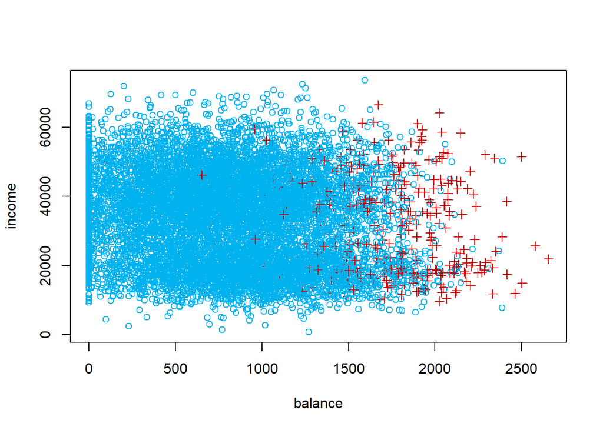

```r
attach(Default)
plot(income~balance,col = c("deepskyblue2","red3")[default],pch = c(1, 3)[default])
```

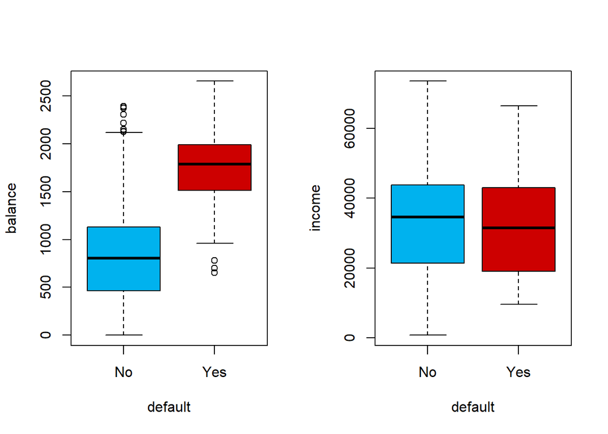

```r
par(mfrow=c(1,2))
boxplot(balance~default,col=c("deepskyblue2","red3"))
boxplot(income~default,col=c("deepskyblue2","red3"))
```

- Model:
  - For the data, logistic regression models the probability of default. For example, the probability of default given $X$ can be written as
    $${\displaystyle
    \operatorname Pr(Y=1|balance)=Pr(Y='Yes'|balance)=Pr(balance)={\begin{cases}\text{Yes}&{\text{,if }}>0.5\\{\text{No}
    }&{\text{,otherwise}}.\end{cases}}}$$
- Using a linear regression model to represent these probabilities:  
  $P(X)=\beta_0+\beta X$ These predictions are not sensible, since the prob. Most fall between 0 to 1.
- Taking log-odds or logit:
  $${\displaystyle p(Y=1|X)={\frac
  {1}{1+e^{-(\beta_{0}+\beta _{1}x)}}}}$$

$${\displaystyle {\frac
{p(x)}{1-p(x)}}=e^{\beta _{0}+\beta _{1}x}.}$$

> $log{\frac {p(x)}{1-p(x)}}$ range is between ($-\infty$,$\infty$)
- Estimation the likelihood function:  
  Consider a generalized linear model function parameterized by ${\displaystyle \theta }$,

$${\displaystyle h_{\theta }(X)={\frac
{1}{1+e^{-\theta ^{T}X}}}=\Pr(Y=1\mid X;\theta )}$$

Therefore,

$${\displaystyle \Pr(Y=0\mid X;\theta
)=1-h_{\theta }(X)}$$

and since ${\displaystyle Y\in \{0,1\}}$, we see that ${\displaystyle \Pr(y\mid X;\theta )}$ is given by ${\displaystyle \Pr(y\mid X;\theta )=h_{\theta }(X)^{y}(1-h_{\theta }(X))^{(1-y)}.}$ We now calculate the likelihood function assuming that all the observations in the sample are independently Bernoulli distributed,
$${\displaystyle {\begin{aligned}L(\theta \mid
y;x)&=\Pr(Y\mid X;\theta )\\&=\prod _{i}\Pr(y_{i}\mid
x_{i};\theta )\\&=\prod _{i}h_{\theta }(x_{i})^{y_{i}}(1-h_{\theta
}(x_{i}))^{(1-y_{i})}\end{aligned}}}$$
To obtain $\hat\beta_0,\hat\beta_1$:

$$l(\beta_0,\beta_1)=\prod
_{i=1}^{n}P(x_{i})^{y_{i}}(1-P(x_{i}))^{(1-y_{i})}$$
$\hat\beta_0,\hat\beta_1$ are chosen to maximize $l(\beta_0,\beta_1)$

- Making Prediction
- Multiple Logistic regression
- Multiple-Class (K>2)  
  The two-class logistic regression models have multiple-class extensions, but in practice they tend not to be used all that often.

### LDA

- Why not using logistic regression
  - When there is $\color{blue}{\text{well-separated}}$ between the two classes, the parameter estimates for the logistic regression model are surprisingly $\color{blue}{\text{unstable}}$. The methods that we consider in this section do not suffer from this problem.
  - If the distribution of the predictors $X$ is approximately normal in each of the classes and the sample size is small, then the approaches in this section may be more accurate than logistic regression.(If $n$ is small and the distribution of the predictors $X$ is approximately normal in each of the classes,LDA is again more stable than the logistic model.)
  - As mentioned in last page, linear discriminant analysis is popular when we have more than two response classes.
- Using Bayes’ Theorem for Classification
  - Rules of multiplication
    $$P(A\cap
    B)=P(A)P(B|A=P(B)P(A|B))$$
  - Bayes’ Thm ${A_1,...,A_n}$ is a partition of the sample space ($\Omega$) $P(A_i|B)=\frac{P(A_i)P(B|A_i)}{\sum _{j=1} ^{n} {P(A_j)P(B|A_j)}}$
  - Let $\pi _k$ represent the overall or prior probability that a randomly chosen observation comes from the $k$th class; this is the probability that a given observation is associated with the $k$th category of the response variable $Y$. Let $f_k(x)=P(X=x|Y=k)$ denote the density function of X for an observation that comes from the $k$th class. In other words, $f_k(x)$ is relatively large if there is a high probability that an observation in the $k$th class has $X ≈ x$. The Bayes Thm states that
    $$P(X=x|Y=k)=\frac{\pi_k f_k(x)}{\sum_{l=1}^{k}
    {\pi_l}{f_l(x)}}$$

we will use the abbreviation $P_k(x)=P(Y=k|X=x)$. In general, estimating $π_k$ is easy if we have a random sample of $Y$ s from the population: we simply compute the fraction of the training observations that belong to the $k$th class. However, estimating $f_k(X)$ tends to be more challenging, unless we assume some simple forms for these densities. We refer to $p_k(x)$ as $\color{blue}{\text{the posterior prob}}$ that an observation $X = x$ belongs to the $k$thclass. That is, **it is the probability that the observation belongs to the $k$th class**, given the predictor value for that observation.

> ex:  
> n=100, 25 obs from 1st class $\pi_k$  
> $\Rightarrow \hat\pi_1=\frac{25}{100}$